# python pre

```python
import pandas as pd
import numpy as np
import matplotlib.pyplot as plt
```

```python
df = pd.read_csv("Students Social Media Addiction.csv")
df.head()
```

|  | Student_ID | Age | Gender | Academic_Level | Country | Avg_Daily_Usage_Hours | Most_Used_Platform | Affects_Academic_Performance | Sleep_Hours_Per_Night | Mental_Health_Score | Relationship_Status | Conflicts_Over_Social_Media | Addicted_Score |
| --- | --- | --- | --- | --- | --- | --- | --- | --- | --- | --- | --- | --- | --- |
| 0 | 1 | 19 | Female | Undergraduate | Bangladesh | 5.2 | Instagram | Yes | 6.5 | 6 | In Relationship | 3 | 8 |
| 1 | 2 | 22 | Male | Graduate | India | 2.1 | Twitter | No | 7.5 | 8 | Single | 0 | 3 |
| 2 | 3 | 20 | Female | Undergraduate | USA | 6.0 | TikTok | Yes | 5.0 | 5 | Complicated | 4 | 9 |
| 3 | 4 | 18 | Male | High School | UK | 3.0 | YouTube | No | 7.0 | 7 | Single | 1 | 4 |
| 4 | 5 | 21 | Male | Graduate | Canada | 4.5 | Facebook | Yes | 6.0 | 6 | In Relationship | 2 | 7 |

Check the data structure and basic information.

# Introduction

In this project, we analyse the Kaggle dataset “Students Social Media Addiction” (705 observations). Our goals are to understand: – How much time students spend on social media – How social media use is related to sleep, mental health, and conflicts – Whether usage and addiction differ by gender and academic level

```python
# Check the data structure and basic information.
df.info()
```

```
<class 'pandas.core.frame.DataFrame'>
RangeIndex: 705 entries, 0 to 704
Data columns (total 13 columns):
 #   Column                        Non-Null Count  Dtype
---  ------                        --------------  -----
 0   Student_ID                    705 non-null    int64
 1   Age                           705 non-null    int64
 2   Gender                        705 non-null    object
 3   Academic_Level                705 non-null    object
 4   Country                       705 non-null    object
 5   Avg_Daily_Usage_Hours         705 non-null    float64
 6   Most_Used_Platform            705 non-null    object
 7   Affects_Academic_Performance  705 non-null    object
 8   Sleep_Hours_Per_Night         705 non-null    float64
 9   Mental_Health_Score           705 non-null    int64
 10  Relationship_Status           705 non-null    object
 11  Conflicts_Over_Social_Media   705 non-null    int64
 12  Addicted_Score                705 non-null    int64
dtypes: float64(2), int64(5), object(6)
memory usage: 71.7+ KB
```

```python
# Check missing values
df.isnull().sum()
```

```
Student_ID                      0
Age                             0
Gender                          0
Academic_Level                  0
Country                         0
Avg_Daily_Usage_Hours           0
Most_Used_Platform              0
Affects_Academic_Performance    0
Sleep_Hours_Per_Night           0
Mental_Health_Score             0
Relationship_Status             0
Conflicts_Over_Social_Media     0
Addicted_Score                  0
dtype: int64
```

```python
# Descriptive statistics for numeric columns
df.describe()
```

|  | Student_ID | Age | Avg_Daily_Usage_Hours | Sleep_Hours_Per_Night | Mental_Health_Score | Conflicts_Over_Social_Media | Addicted_Score |
| --- | --- | --- | --- | --- | --- | --- | --- |
| count | 705.000000 | 705.000000 | 705.000000 | 705.000000 | 705.000000 | 705.000000 | 705.000000 |
| mean | 353.000000 | 20.659574 | 4.918723 | 6.868936 | 6.226950 | 2.849645 | 6.436879 |
| std | 203.660256 | 1.399217 | 1.257395 | 1.126848 | 1.105055 | 0.957968 | 1.587165 |
| min | 1.000000 | 18.000000 | 1.500000 | 3.800000 | 4.000000 | 0.000000 | 2.000000 |
| 25% | 177.000000 | 19.000000 | 4.100000 | 6.000000 | 5.000000 | 2.000000 | 5.000000 |
| 50% | 353.000000 | 21.000000 | 4.800000 | 6.900000 | 6.000000 | 3.000000 | 7.000000 |
| 75% | 529.000000 | 22.000000 | 5.800000 | 7.700000 | 7.000000 | 4.000000 | 8.000000 |
| max | 705.000000 | 24.000000 | 8.500000 | 9.600000 | 9.000000 | 5.000000 | 9.000000 |

### Data preparation

In this part, we prepare the dataset before the analysis.  
We rename some columns to make them easier to read, and we create a new variable to identify high social media usage.

```python
# Rename some columns to shorter names
df = df.rename(columns={
    'Avg_Daily_Usage_Hours': 'Usage_Hours',
    'Sleep_Hours_Per_Night': 'Sleep_Hours'
})

# Create a new column: high vs normal usage (threshold = 5 hours per day)
df['High_Usage'] = np.where(df['Usage_Hours'] > 5, 'High', 'Normal')

# Check the result
df[['Usage_Hours', 'Sleep_Hours', 'High_Usage']].head()
```

|  | Usage_Hours | Sleep_Hours | High_Usage |
| --- | --- | --- | --- |
| 0 | 5.2 | 6.5 | High |
| 1 | 2.1 | 7.5 | Normal |
| 2 | 6.0 | 5.0 | High |
| 3 | 3.0 | 7.0 | Normal |
| 4 | 4.5 | 6.0 | Normal |

```python
#Confirm whether there is any missing data.
missing_values = df.isnull().sum()
print(missing_values)
```

```
Student_ID                      0
Age                             0
Gender                          0
Academic_Level                  0
Country                         0
Usage_Hours                     0
Most_Used_Platform              0
Affects_Academic_Performance    0
Sleep_Hours                     0
Mental_Health_Score             0
Relationship_Status             0
Conflicts_Over_Social_Media     0
Addicted_Score                  0
High_Usage                      0
dtype: int64
```

```python
#Check for any abnormal value.
df.describe()
```

|  | Student_ID | Age | Usage_Hours | Sleep_Hours | Mental_Health_Score | Conflicts_Over_Social_Media | Addicted_Score |
| --- | --- | --- | --- | --- | --- | --- | --- |
| count | 705.000000 | 705.000000 | 705.000000 | 705.000000 | 705.000000 | 705.000000 | 705.000000 |
| mean | 353.000000 | 20.659574 | 4.918723 | 6.868936 | 6.226950 | 2.849645 | 6.436879 |
| std | 203.660256 | 1.399217 | 1.257395 | 1.126848 | 1.105055 | 0.957968 | 1.587165 |
| min | 1.000000 | 18.000000 | 1.500000 | 3.800000 | 4.000000 | 0.000000 | 2.000000 |
| 25% | 177.000000 | 19.000000 | 4.100000 | 6.000000 | 5.000000 | 2.000000 | 5.000000 |
| 50% | 353.000000 | 21.000000 | 4.800000 | 6.900000 | 6.000000 | 3.000000 | 7.000000 |
| 75% | 529.000000 | 22.000000 | 5.800000 | 7.700000 | 7.000000 | 4.000000 | 8.000000 |
| max | 705.000000 | 24.000000 | 8.500000 | 9.600000 | 9.000000 | 5.000000 | 9.000000 |

# QUESTION 1: SOCIAL MEDIA USAGE DISTRIBUTION

```python
# 1. Average daily usage hours
avg_usage = df['Usage_Hours'].mean()
print(f"\nAverage daily usage: {avg_usage:.2f} hours per day")
```

```
Average daily usage: 4.92 hours per day
```

```python
# 2. Addiction score distribution (summary stats)
print("\nAddiction score distribution:")
print(df['Addicted_Score'].describe())
```

```
Addiction score distribution:
count    705.000000
mean       6.436879
std        1.587165
min        2.000000
25%        5.000000
50%        7.000000
75%        8.000000
max        9.000000
Name: Addicted_Score, dtype: float64
```

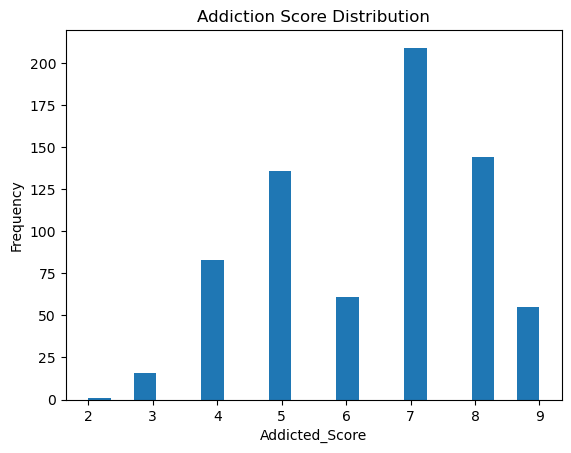

```python
# ---- Visualizations ----
# Addiction score histogram
df['Addicted_Score'].plot(kind='hist', bins=20, title="Addiction Score Distribution")
plt.xlabel("Addicted_Score")
plt.show()
```

```python
# 3. Platform proportions
platform_counts = df['Most_Used_Platform'].value_counts()
platform_percent = (platform_counts / len(df) * 100).round(2)
print("\nPlatform proportions (%):")
print(platform_percent)
```

```
Platform proportions (%):
Most_Used_Platform
Instagram    35.32
TikTok       21.84
Facebook     17.45
WhatsApp      7.66
Twitter       4.26
LinkedIn      2.98
WeChat        2.13
Snapchat      1.84
LINE          1.70
KakaoTalk     1.70
VKontakte     1.70
YouTube       1.42
Name: count, dtype: float64
```

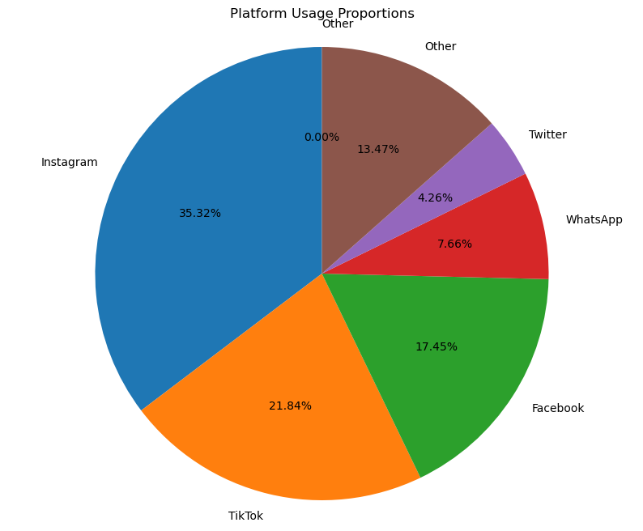

```python
threshold = 3
small_platforms = platform_percent[platform_percent < threshold]
other = pd.Series([small_platforms.sum()], index=['Other'])
# use pd.concat to combine to a new series
platform_percent = pd.concat([platform_percent[platform_percent >= threshold], other])

labels = platform_percent.index
sizes = platform_percent.values

plt.figure(figsize=(10, 8))
plt.pie(sizes, labels=labels, autopct='%1.2f%%', startangle=90, textprops={'fontsize': 10})
plt.axis('equal')
plt.title('Platform Usage Proportions')
plt.show()
```

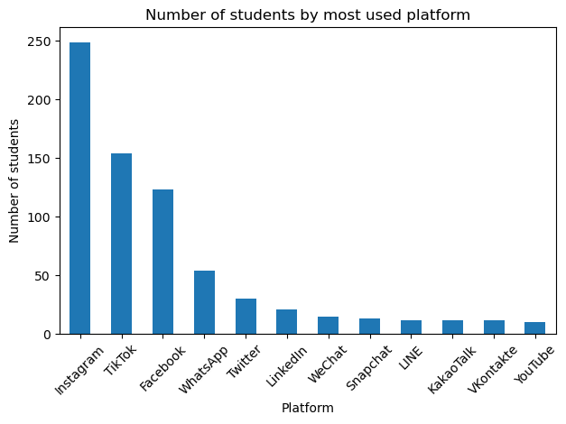

```python
platform_counts = df['Most_Used_Platform'].value_counts()

platform_counts.plot(kind='bar')
plt.title('Number of students by most used platform')
plt.xlabel('Platform')
plt.ylabel('Number of students')
plt.xticks(rotation=45)
plt.tight_layout()
plt.show()
```

# QUESTION 2: GROUP COMPARISONS

```python
# 1. Average usage, sleep, and mental health by gender
gender_means = df.groupby('Gender')[['Usage_Hours', 'Sleep_Hours', 'Mental_Health_Score']].mean().round(2)
print("\nAverage values by Gender:")
print(gender_means)
```

```
Average values by Gender:
        Usage_Hours  Sleep_Hours  Mental_Health_Score
Gender
Female         5.01         6.82                 6.18
Male           4.83         6.92                 6.28
```

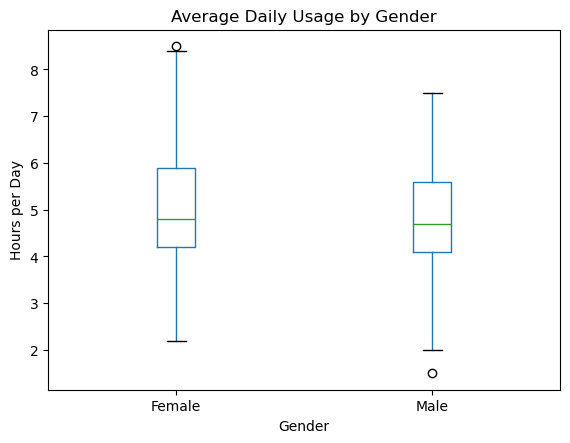

```python
# ---- Visualizations ----
# Boxplot of daily usage by gender
df.boxplot(column='Usage_Hours', by='Gender', grid=False)
plt.title("Average Daily Usage by Gender")
plt.suptitle("")
plt.ylabel("Hours per Day")
plt.show()
```

```python
# 2. Addiction score distribution by academic level
level_addiction = df.groupby('Academic_Level')['Addicted_Score'].describe().round(2)
print("\nAddiction score distribution by Academic Level:")
print(level_addiction)
```

```
Addiction score distribution by Academic Level:
                count  mean   std  min  25%  50%  75%  max
Academic_Level
Graduate        325.0  6.24  1.49  2.0  5.0  7.0  7.0  9.0
High School      27.0  8.04  1.13  4.0  8.0  8.0  9.0  9.0
Undergraduate   353.0  6.49  1.63  3.0  5.0  7.0  8.0  9.0
```

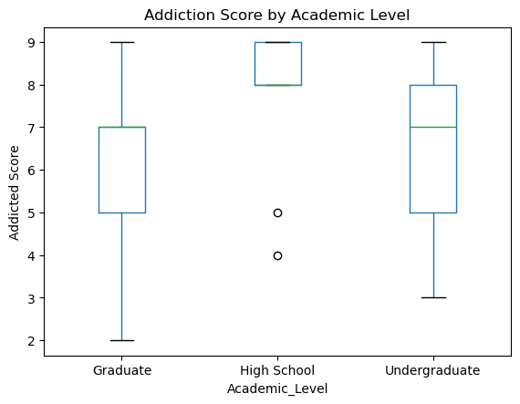

```python
# Boxplot of addiction score by academic level
df.boxplot(column='Addicted_Score', by='Academic_Level', grid=False)
plt.title("Addiction Score by Academic Level")
plt.suptitle("")
plt.ylabel("Addicted Score")
plt.show()
```

### Findings

```python
def compute_stats(series):
    return pd.Series({
        'Mean': round(series.mean(), 2),
        'Std': round(series.std(), 2)
    })
```

```python
cols = ['Usage_Hours', 'Sleep_Hours', 'Mental_Health_Score', 'Addicted_Score']
```

```python
results = pd.DataFrame()

for c in cols:
    results[c] = compute_stats(df[c])

results
```

|  | Usage_Hours | Sleep_Hours | Mental_Health_Score | Addicted_Score |
| --- | --- | --- | --- | --- |
| Mean | 4.92 | 6.87 | 6.23 | 6.44 |
| Std | 1.26 | 1.13 | 1.11 | 1.59 |

## QUESTION 3: Correlation Analysis

What is the relationship between social media usage hours and sleep duration, mental health scores, and addiction scores?

```python
from scipy import stats
# Show basic info
print(df.shape)
print(df.columns)
df.head()
```

```
(705, 14)
Index(['Student_ID', 'Age', 'Gender', 'Academic_Level', 'Country',
       'Usage_Hours', 'Most_Used_Platform', 'Affects_Academic_Performance',
       'Sleep_Hours', 'Mental_Health_Score', 'Relationship_Status',
       'Conflicts_Over_Social_Media', 'Addicted_Score', 'High_Usage'],
      dtype='object')
```

|  | Student_ID | Age | Gender | Academic_Level | Country | Usage_Hours | Most_Used_Platform | Affects_Academic_Performance | Sleep_Hours | Mental_Health_Score | Relationship_Status | Conflicts_Over_Social_Media | Addicted_Score | High_Usage |
| --- | --- | --- | --- | --- | --- | --- | --- | --- | --- | --- | --- | --- | --- | --- |
| 0 | 1 | 19 | Female | Undergraduate | Bangladesh | 5.2 | Instagram | Yes | 6.5 | 6 | In Relationship | 3 | 8 | High |
| 1 | 2 | 22 | Male | Graduate | India | 2.1 | Twitter | No | 7.5 | 8 | Single | 0 | 3 | Normal |
| 2 | 3 | 20 | Female | Undergraduate | USA | 6.0 | TikTok | Yes | 5.0 | 5 | Complicated | 4 | 9 | High |
| 3 | 4 | 18 | Male | High School | UK | 3.0 | YouTube | No | 7.0 | 7 | Single | 1 | 4 | Normal |
| 4 | 5 | 21 | Male | Graduate | Canada | 4.5 | Facebook | Yes | 6.0 | 6 | In Relationship | 2 | 7 | Normal |

```python
# Select relevant columns
cols = ["Usage_Hours", "Sleep_Hours", "Mental_Health_Score", "Addicted_Score"]
data = df[cols].copy()

# Convert to numeric (in case of strings)
for c in cols:
    data[c] = pd.to_numeric(data[c], errors="coerce")

# Drop rows with missing values
data = data.dropna()
print("Final sample size:", len(data))
data.describe()
```

```
Final sample size: 705
```

|  | Usage_Hours | Sleep_Hours | Mental_Health_Score | Addicted_Score |
| --- | --- | --- | --- | --- |
| count | 705.000000 | 705.000000 | 705.000000 | 705.000000 |
| mean | 4.918723 | 6.868936 | 6.226950 | 6.436879 |
| std | 1.257395 | 1.126848 | 1.105055 | 1.587165 |
| min | 1.500000 | 3.800000 | 4.000000 | 2.000000 |
| 25% | 4.100000 | 6.000000 | 5.000000 | 5.000000 |
| 50% | 4.800000 | 6.900000 | 6.000000 | 7.000000 |
| 75% | 5.800000 | 7.700000 | 7.000000 | 8.000000 |
| max | 8.500000 | 9.600000 | 9.000000 | 9.000000 |

After data preprocessing, we further quantify the linear relationships between the core variables, with specific explanations as follows:

Correlation Analysis

1. Research Objective: To quantify the linear correlations between average daily mobile phone usage hours and key variables (nightly sleep duration, mental health score, and addiction score).
2. Analysis Method: Pearson product-moment correlation coefficient is adopted, which is suitable for scenarios where both variables are continuous and approximately normally distributed. It mainly measures the strength and direction of the linear association between variables.
3. Result Explanation: By outputting the correlation coefficient (r-value) and significance level (p-value), the reliability and degree of association between variables are clarified. The r-value ranges from [-1, 1], and p<0.05 indicates that the association is statistically significant.

```python
# Pearson correlations
pearson_results = {}

for target in ["Sleep_Hours", "Mental_Health_Score", "Addicted_Score"]:
    r, p = stats.pearsonr(data["Usage_Hours"], data[target])
    pearson_results[target] = (r, p)

print("Pearson correlation results:")
for k, v in pearson_results.items():
    print(f"Usage vs {k}: r = {v[0]:.3f}, p = {v[1]:.5f}")
```

```
Pearson correlation results:
Usage vs Sleep_Hours: r = -0.791, p = 0.00000
Usage vs Mental_Health_Score: r = -0.801, p = 0.00000
Usage vs Addicted_Score: r = 0.832, p = 0.00000
```

Considering the potential deviation of data from normal distribution or the presence of ordinal variables, we further conduct non-parametric correlation analysis to verify the robustness of the results. Specific explanations are as follows:

1. Research Objective: To verify the robustness of the associations between average daily mobile phone usage hours, nightly sleep duration, mental health score, and addiction score, avoiding biases caused by unmet normal distribution assumptions;
2. Analysis Method: Spearman's rank correlation coefficient is adopted, a non-parametric statistical method that does not require data to be normally distributed. It is suitable for continuous and ordinal categorical variables, focusing on measuring the strength and direction of the monotonic association between variables;
3. Result Explanation: The rank correlation coefficient (ρ-value, rho) and significance level (p-value) are output. The ρ-value ranges from [-1, 1], and p<0.05 indicates that the monotonic association is statistically significant. The results can be cross-validated with Pearson correlation analysis.

```python
# Spearman correlations
spearman_results = {}

for target in ["Sleep_Hours", "Mental_Health_Score", "Addicted_Score"]:
    r, p = stats.spearmanr(data["Usage_Hours"], data[target])
    spearman_results[target] = (r, p)

print("Spearman correlation results:")
for k, v in spearman_results.items():
    print(f"Usage vs {k}: rho = {v[0]:.3f}, p = {v[1]:.5f}")
```

```
Spearman correlation results:
Usage vs Sleep_Hours: rho = -0.814, p = 0.00000
Usage vs Mental_Health_Score: rho = -0.802, p = 0.00000
Usage vs Addicted_Score: rho = 0.838, p = 0.00000
```

```python
corr_matrix = data.corr(method='pearson')
print("Pearson correlation matrix:")
print(corr_matrix.round(3))
```

```
Pearson correlation matrix:
                     Usage_Hours  Sleep_Hours  Mental_Health_Score  \
Usage_Hours                1.000       -0.791               -0.801
Sleep_Hours               -0.791        1.000                0.707
Mental_Health_Score       -0.801        0.707                1.000
Addicted_Score             0.832       -0.765               -0.945

                     Addicted_Score
Usage_Hours                   0.832
Sleep_Hours                  -0.765
Mental_Health_Score          -0.945
Addicted_Score                1.000
```

To intuitively show the association trends between average daily mobile phone usage hours and key variables, scatter plots with linear fitting lines are used for visualization. The red fitting line reflects the overall linear change trend between variables, and the scatter distribution shows the actual association of individual data.

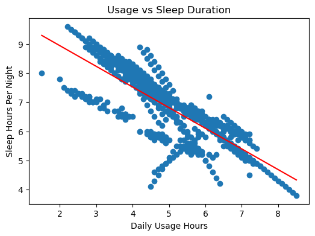

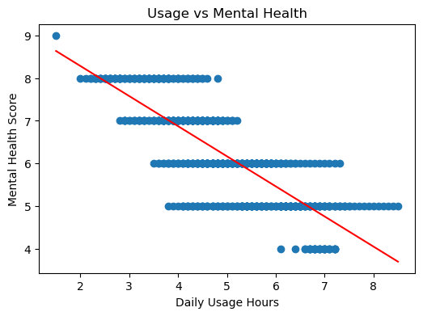

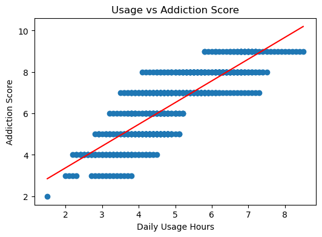

```python
def scatter_with_fit(x, y, xlabel, ylabel, title):
    plt.figure(figsize=(6,4))
    plt.scatter(x, y)
    m, b = np.polyfit(x, y, 1)
    xs = np.linspace(x.min(), x.max(), 100)
    plt.plot(xs, m*xs + b, color='red')
    plt.title(title)
    plt.xlabel(xlabel)
    plt.ylabel(ylabel)
    plt.show()

scatter_with_fit(data["Usage_Hours"], data["Sleep_Hours"],
                 "Daily Usage Hours", "Sleep Hours Per Night",
                 "Usage vs Sleep Duration")

scatter_with_fit(data["Usage_Hours"], data["Mental_Health_Score"],
                 "Daily Usage Hours", "Mental Health Score",
                 "Usage vs Mental Health")

scatter_with_fit(data["Usage_Hours"], data["Addicted_Score"],
                 "Daily Usage Hours", "Addiction Score",
                 "Usage vs Addiction Score")
```

### **Question 4: Platform-Specific Problem: What are the differences in usage habits and impacts among users of different social media platforms?**

```python
# Measuring the academic impact
df['Academic_Impact'] = df['Affects_Academic_Performance'].map({'Yes': 1, 'No': 0, 1:1, 0:0})
```

```python
#Based on the platform, calculate the average daily usage duration,
# the average academic impact and the average conflicts.
avg = df.groupby('Most_Used_Platform')[['Usage_Hours','Academic_Impact','Conflicts_Over_Social_Media']].mean()
avg
```

| Most_Used_Platform | Usage_Hours | Academic_Impact | Conflicts_Over_Social_Media |
| --- | --- | --- | --- |
| Facebook | 4.507317 | 0.300813 | 2.430894 |
| Instagram | 4.872289 | 0.690763 | 2.939759 |
| KakaoTalk | 4.725000 | 1.000000 | 3.000000 |
| LINE | 3.250000 | 0.000000 | 1.000000 |
| LinkedIn | 2.519048 | 0.000000 | 0.904762 |
| Snapchat | 5.092308 | 0.923077 | 3.230769 |
| TikTok | 5.346104 | 0.935065 | 3.409091 |
| Twitter | 4.870000 | 0.366667 | 2.433333 |
| VKontakte | 4.250000 | 0.000000 | 2.000000 |
| WeChat | 4.960000 | 0.533333 | 2.533333 |
| WhatsApp | 6.475926 | 1.000000 | 3.462963 |
| YouTube | 4.080000 | 0.300000 | 2.200000 |

```python
# Format and organize the results
summary = pd.DataFrame({
    'avg_usage_hour': avg['Usage_Hours'].round(2),
    'Avg_Academic_Impact': avg['Academic_Impact'].round(2),
    'avg_conflict': avg['Conflicts_Over_Social_Media'].round(2)
})

print(summary)
```

```
                    avg_usage_hour  Avg_Academic_Impact  avg_conflict
Most_Used_Platform
Facebook                      4.51                 0.30          2.43
Instagram                     4.87                 0.69          2.94
KakaoTalk                     4.73                 1.00          3.00
LINE                          3.25                 0.00          1.00
LinkedIn                      2.52                 0.00          0.90
Snapchat                      5.09                 0.92          3.23
TikTok                        5.35                 0.94          3.41
Twitter                       4.87                 0.37          2.43
VKontakte                     4.25                 0.00          2.00
WeChat                        4.96                 0.53          2.53
WhatsApp                      6.48                 1.00          3.46
YouTube                       4.08                 0.30          2.20
```

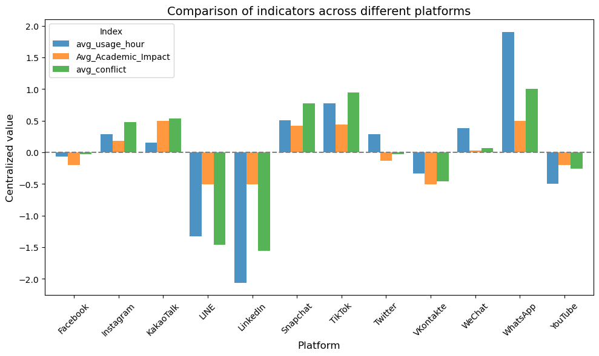

```python
# Copy the original data
summary_centered = summary.copy()
#Calculate the mean of each indicator.
for metric in summary.columns:
    metric_mean = summary[metric].mean()
# Center the value of each of this indicator
    summary_centered[metric] = summary[metric].map(lambda x: x - metric_mean)
summary_centered.plot(
    kind='bar',
    figsize=(10, 6),
    width=0.8,
    alpha=0.8
)
#visualization
plt.title("Comparison of indicators across different platforms", fontsize=14)
plt.xlabel("Platform", fontsize=12)
plt.ylabel("Centralized value", fontsize=12)
# Add mean reference line（y=0）
plt.axhline(y=0, color='gray', linestyle='--')
plt.xticks(rotation=45)
plt.legend(title='Index')
plt.tight_layout()
plt.show()
```

**1. Significant differences in usage habits**: Users of WhatsApp and TikTok have significantly higher daily usage durations than the average, making them the most frequent users; in contrast, LinkedIn and LINE users have much lower usage durations, with infrequent usage.

**2. Divergent performance in social conflicts**: Platforms with high usage intensity (such as WhatsApp and TikTok) are accompanied by more social media conflicts; meanwhile, users of low-usage platforms like LinkedIn and LINE experience very few conflicts, forming a stark contrast.

These differences indicate that there is a certain correlation between usage intensity and social conflicts, and the academic impact of different platforms on users varies significantly—closely linked to platforms' functional positioning (e.g., social attributes, professional attributes).

# Question 5： Threshold Exploration Problem: Is there a "critical point" in usage hours beyond which negative impacts increase?

```python
# The list of stored results
results = []
# Iterate from threshold 1 to 9
for threshold in range(1, 10):
# Iterate through the thresholds from 1 to 9 to divide the population into "above the threshold" and "below the threshold" groups.
    above_threshold = df['Usage_Hours'] > threshold
    below_threshold = ~above_threshold  # On the contrary, "not exceeding the threshold"

    # Calculate the difference in academic impact (above average - below average)
    academic_above = df.loc[above_threshold, 'Academic_Impact'].mean()
    academic_below = df.loc[below_threshold, 'Academic_Impact'].mean()
    academic_diff = academic_above - academic_below

    # Calculate the difference in mental health scores (above average - below average)
    mental_above = df.loc[above_threshold, 'Mental_Health_Score'].mean()
    mental_below = df.loc[below_threshold, 'Mental_Health_Score'].mean()
    mental_diff = mental_above - mental_below

    # save the result
    results.append({
        'Threshold': threshold,
        'AcademicImpactDiff': academic_diff,
        'MentalHealthDiff': mental_diff
    })

# transfer to DataFrame
results_df = pd.DataFrame(results)
```

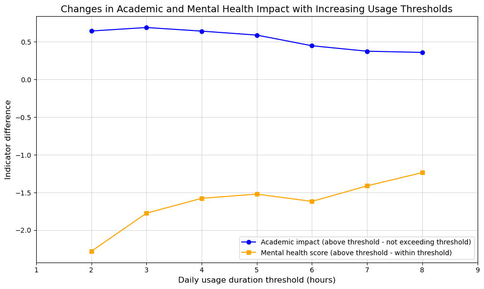

```python
# visualisation
plt.figure(figsize=(10, 6))
plt.plot(
    results_df['Threshold'],
    results_df['AcademicImpactDiff'],
    label='Academic impact (above threshold - not exceeding threshold)',
    marker='o',  # Add marking points to facilitate the observation of key points.
    color='blue'
)
plt.plot(
    results_df['Threshold'],
    results_df['MentalHealthDiff'],
    label='Mental health score (above threshold - within threshold)',
    marker='s',  # Different marking points distinguish indicators
    color='orange'
)

# change the label of the figure
plt.xlabel('Daily usage duration threshold (hours)', fontsize=12)
plt.ylabel('Indicator difference', fontsize=12)
plt.title('Changes in Academic and Mental Health Impact with Increasing Usage Thresholds', fontsize=14)
plt.xticks(range(1, 10))
plt.legend()
plt.grid(alpha=0.5)
plt.tight_layout()
plt.show()
```

**1. Academic performance impact (blue line)**

1. Across all thresholds, the blue line stays **above zero**: groups exceeding the threshold consistently show worse academic performance.
2. As the threshold rises, the academic impact difference shrinks—once usage is already high, adding more hours doesn’t significantly worsen academic outcomes.

**2. Mental health score (orange line)**